# Calendar plot in R using ggplot2

### Vertical yearly calendar

It is worth to mention that you can also create yearly calendars in R in portrait mode. For that purpose, you will need to set the argument `orientation` as `"portrait"` or as `"p"`. This configuration will lead to a three column calendar.

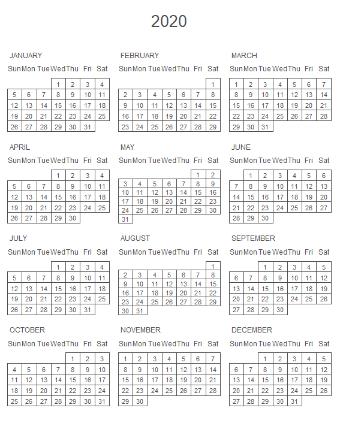

```r
calendR(orientation = "portrait", # Equivalent to: orientation = "p"
        months.pos = 0)           # Month names aligned to the left
```

## Monthly calendar plot in R

**The previously described features of the yearly calendar are also available for monthly calendars**. Nonetheless, monthly calendars also allows you to **add text to the days of the month** if desired.

In order to create a monthly calendar you will need to specify both the year and the month as follows:

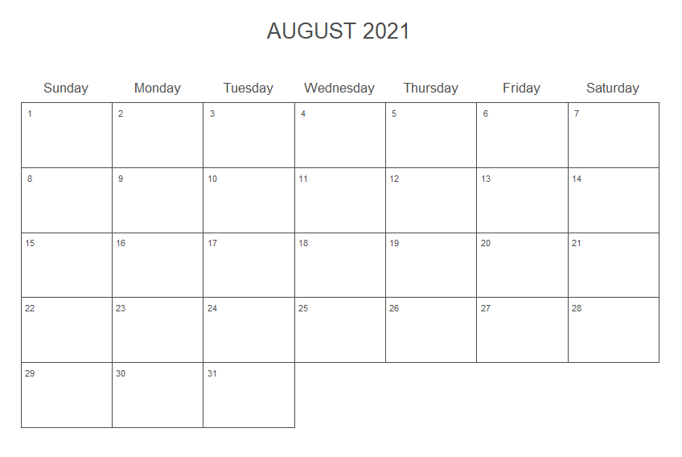

```r
calendR(year = 2021, month = 8)
```